# Understanding data in reduced dimensions

Diana Murray

June 25, 2018

# About this activity

In the last presentation, we learned that an unsupervised analysis can be used to explore large data sets (with many genes and/or many samples).Every data set has its own unique personality, and whenever I am confronted with a new one, I always do an unsupervised analysis first to get to know it. These initial analyses will oftentimes reveal idiosyncracies in the data (such as *batch effects*) that may confound the interpretation of the results.

# Loading and inspecting the data

Run the chunk below to pre-load and format some data that you’ll be using for the activity below. Feel free to review the individual steps (**hint:** they’re similar to the transformations we applied in Module 1), but otherwise we’ll jump right into inspecting and working with the data!

```r
load(file.path(data_dir, "pson_expr_tpm_df.RData"))
load(file.path(data_dir, "pson_expr_gene_info.RData"))
load(file.path(data_dir, "pson_motility_tidy_df.RData"))
pson_pca_inputs_file <- file.path(data_dir, "pson_pca_inputs.RData")
if (!file.exists(pson_pca_inputs_file)) {
  pson_expr_tpm_df2 <- merge(x = gene_df, y = pson_expr_tpm_df,
                             by.x = "gene_id", by.y = "gene_id")
  pson_tpm_mat <- as.matrix(pson_expr_tpm_df2[, -c(1:5)])
  rownames(pson_tpm_mat) <- pson_expr_tpm_df2$symbol
  pson_logtpm_mat <- log2(1 + pson_tpm_mat)
  pson_pca_mat <- t(pson_logtpm_mat)
  save(list = c("pson_pca_mat", "pson_logtpm_mat"),
       file = pson_pca_inputs_file)
} else {
  load(pson_pca_inputs_file)
}
```

Check out `pson_expr_tpm_df`:

```r
# How do you see what is included in this data frame? Run the command.
str(pson_expr_tpm_df) # TODO: DELETE BEFORE ACTIVITY
```

```
Classes ‘tbl_df’, ‘tbl’ and 'data.frame':   18682 obs. of  64 variables:
 $ gene_id : chr  "ENSG00000000003" "ENSG00000000005" "ENSG00000000419" "ENSG00000000457" ...
 $ mRNA_R17: num  33.56 0 169.46 1.85 5.73 ...
 $ mRNA_R21: num  45.1 0 129.88 1.85 11.85 ...
 $ mRNA_R20: num  39.42 0 132.06 1.77 10.16 ...
 $ mRNA_R19: num  35.61 0 113.73 1.93 9.28 ...
 $ mRNA_R18: num  32.1 0 123.4 2.3 10 ...
 $ mRNA_R16: num  39.49 0 136.29 1.54 8.93 ...
 $ mRNA_R15: num  29.9 0 137.98 2 7.47 ...
 $ mRNA_R38: num  20.8 0 185.06 1.75 7.92 ...
 $ mRNA_R42: num  19.63 0 135.75 1.41 5.5 ...
 $ mRNA_R41: num  24.6 0 173.8 1.76 8.55 ...
 $ mRNA_R40: num  12.37 0 188.45 0.84 4.33 ...
 $ mRNA_R39: num  18.25 0 173.7 1.54 5.73 ...
 $ mRNA_R37: num  21.11 0 179.63 2.35 5.16 ...
```

[output cut: 50 more lines]

```r
# What are the sample names in `pson_expr_tpm_df`?
colnames(pson_expr_tpm_df)[-1] # TODO: DELETE BEFORE ACTIVITY
```

```
 [1] "mRNA_R17" "mRNA_R21" "mRNA_R20" "mRNA_R19" "mRNA_R18" "mRNA_R16" "mRNA_R15" "mRNA_R38"
 [9] "mRNA_R42" "mRNA_R41" "mRNA_R40" "mRNA_R39" "mRNA_R37" "mRNA_R36" "mRNA_R24" "mRNA_R28"
[17] "mRNA_R27" "mRNA_R26" "mRNA_R25" "mRNA_R23" "mRNA_R22" "mRNA_R45" "mRNA_R49" "mRNA_R48"
[25] "mRNA_R47" "mRNA_R46" "mRNA_R44" "mRNA_R43" "mRNA_R10" "mRNA_R14" "mRNA_R13" "mRNA_R12"
[33] "mRNA_R11" "mRNA_R9"  "mRNA_R8"  "mRNA_R3"  "mRNA_R7"  "mRNA_R6"  "mRNA_R5"  "mRNA_R4"
[41] "mRNA_R2"  "mRNA_R1"  "mRNA_R52" "mRNA_R56" "mRNA_R55" "mRNA_R54" "mRNA_R53" "mRNA_R51"
[49] "mRNA_R50" "mRNA_R31" "mRNA_R35" "mRNA_R34" "mRNA_R33" "mRNA_R32" "mRNA_R30" "mRNA_R29"
[57] "mRNA_R59" "mRNA_R63" "mRNA_R62" "mRNA_R61" "mRNA_R60" "mRNA_R58" "mRNA_R57"
```

```r
# How are genes identified?
pson_expr_tpm_df$gene_id[1:5] # TODO: DELETE BEFORE ACTIVITY
```

```
[1] "ENSG00000000003" "ENSG00000000005" "ENSG00000000419" "ENSG00000000457" "ENSG00000000460"
```

```r
# Andrew taught us many ways to inspect the data. Try this one.
View(pson_expr_tpm_df[1:1000, ]) # only view the first 1000 rows so we don't
                                 # make your browser too unhappy...
```

As you learned, the gene IDs are not very informative — they come from a database called **Ensembl**. More commonly, we would use the **Hugo gene symbols** (https://www.genenames.org/). These are the gene names you are more used to seeing (MYC, BRCA1, etc). We have this information stored in another file.

Check out the first few rows of `gene_df`:

```r
# Run the command to view the first 6 rows of `gene_df`
head(gene_df) # TODO: DELETE BEFORE ACTIVITY
```

| gene_id | entrez | symbol | biotype | description |
| --- | --- | --- | --- | --- |
| ENSG00000000003 | 7105 | TSPAN6 | protein_coding | tetraspanin 6 [Source:HGNC Symbol;Acc:11858] |
| ENSG00000000005 | 64102 | TNMD | protein_coding | tenomodulin [Source:HGNC Symbol;Acc:17757] |
| ENSG00000000419 | 8813 | DPM1 | protein_coding | dolichyl-phosphate mannosyltransferase polypeptide 1, catalytic subunit [Source:HGNC Symbol;Acc:3005] |
| ENSG00000000457 | 57147 | SCYL3 | protein_coding | SCY1-like 3 (S. cerevisiae) [Source:HGNC Symbol;Acc:19285] |
| ENSG00000000460 | 55732 | C1orf112 | protein_coding | chromosome 1 open reading frame 112 [Source:HGNC Symbol;Acc:25565] |
| ENSG00000000938 | 2268 | FGR | protein_coding | feline Gardner-Rasheed sarcoma viral oncogene homolog [Source:HGNC Symbol;Acc:3697] |

We now have a new variable called `pson_pca_mat` that we’ll use for the examples below. Take a look at the first few rows and columns of this matrix, and try to figure out what changes were made to go from `pson_expr_tpm_df` and `gene_df` to what you see. Compare to `pson_logtpm_mat` and see what else is different.

```r
# Take a look at the first few rows and columns of `pson_pca_mat`
pson_pca_mat[1:5, 1:5] # TODO: DELETE BEFORE ACTIVITY
```

```
           TSPAN6 TNMD     DPM1    SCYL3 C1orf112
mRNA_R17 5.111031    0 7.413289 1.510962 2.750607
mRNA_R21 5.526695    0 7.032101 1.510962 3.683696
mRNA_R20 5.336997    0 7.055933 1.469886 3.480265
mRNA_R19 5.194166    0 6.842099 1.550901 3.361768
mRNA_R18 5.048759    0 6.958495 1.722466 3.460743
```

```r
# Take a look at the first few rows and columns of `pson_logtpm_mat`
pson_logtpm_mat[1:5, 1:5] # TODO: DELETE BEFORE ACTIVITY
```

```
         mRNA_R17 mRNA_R21 mRNA_R20 mRNA_R19 mRNA_R18
TSPAN6   5.111031 5.526695 5.336997 5.194166 5.048759
TNMD     0.000000 0.000000 0.000000 0.000000 0.000000
DPM1     7.413289 7.032101 7.055933 6.842099 6.958495
SCYL3    1.510962 1.510962 1.469886 1.550901 1.722466
C1orf112 2.750607 3.683696 3.480265 3.361768 3.460743
```

Besides any normalization (e.g., “log” of expression values), translation (changing gene IDs to symbols), or format conversion (data frame to matrix), we’ve also **transposed** or rotated the data such that genes are now represented by columns and samples by rows. More on why we did this next!

# Getting started with PCA with PS-ON cell line data

We will use the function **`prcomp()`** to run the principal component analysis (PCA) algorithm. We’re interested in checking out the variability and similarity of samples (cell lines) in our data based on their gene expression patterns. To do this, we need to give `prcomp()` a matrix as where the samples are the *rows*, and the features (transcript counts) are the *columns*. If we hadn’t transposed, PCA would still work — but it would instead be telling us about the relationship *between* genes.

## Calculating PCA

We want to make sure that we can connect our expression data to motility measurements. I happen to know that for one sample in `pson_pca_mat`, we’re missing motility data (I cheating a bit and checked in advance, but it makes life easier given our time constraints).

```r
# let's locate and remove the sample with no motility measurement data
pca_mat_samples <- rownames(pson_pca_mat)
missing_row <- which(!(pca_mat_samples %in% pson_motil_tidy_df$sample))
missing_row
```

```
[1] 8
```

```r
pson_pca_mat <- pson_pca_mat[-missing_row, ]
```

As described in our lecture, there are two additional things for us to consider:

- 1. The data should be mean-centered around 0.
- 2. The data should be scaled so that the standard deviation for each gene is 1.

Our features have the same units, and it is often the case that they are not scaled; this is somewhat subjective. “prcomp()” automatically mean-centers the data for us. Scaling is up to us.

```r
pson_pca <- prcomp(pson_pca_mat, scale = FALSE)
```

Exciting, right? But now we can get to our exploratory analysis. What goodies does **`pson_pca`** hold for us?

```r
names(pson_pca)
```

```
[1] "sdev"     "rotation" "center"   "scale"    "x"
```

We discussed these in the lecture. To summarize:

- `sdev`: The standard deviation of the principal components
- `rotation`: The matrix of feature loadings (weights)
- `center`: The feature means that prcomp() subtracted from each feature
- `scale`: The feature standard deviations used in scaling
- `x`: Coordinates of the cell lines projected onto the principal components

```r
dim(pson_pca$sdev)
```

```r
dim(pson_pca$rotation)
```

```
[1] 18682    62
```

```r
dim(pson_pca$center)
```

```r
dim(pson_pca$scale)
```

```r
dim(pson_pca$x)
```

```
[1] 62 62
```

Are these dimensions what you would expect?

```r
pson_pca$rotation[1:5, 1:5]
```

```
                   PC1           PC2           PC3           PC4           PC5
TSPAN6    1.584158e-04 -4.610167e-03  5.191321e-03  3.180007e-03  1.729562e-02
TNMD      2.753341e-05  1.197326e-05 -2.777844e-06 -2.525294e-05  1.860216e-06
DPM1     -5.799012e-04 -1.316543e-03  7.183747e-03 -6.022465e-04 -1.600115e-03
SCYL3    -2.893989e-03  1.230555e-02 -1.404974e-03  7.094512e-04 -2.288287e-03
C1orf112 -2.880724e-03  1.562732e-03  9.381906e-04  1.681514e-03  2.043382e-03
```

```r
pson_pca$x[1:5, 1:5]
```

```
               PC1       PC2       PC3         PC4      PC5
mRNA_R17 -39.74973 -76.79247  6.395282  -1.5573725 34.99499
mRNA_R21 -44.31163 -70.45641 16.540568  -5.2920620 50.47853
mRNA_R20 -45.41556 -80.75207  9.007610  -0.0308181 42.11339
mRNA_R19 -42.46163 -73.68480 13.031576  -3.3063448 45.94905
mRNA_R18 -37.95296 -62.22346 19.415076 -10.2662479 43.98570
```

```r
length(pson_pca$sdev)
```

```
[1] 62
```

```r
length(pson_pca$center)
```

```
[1] 18682
```

```r
length(pson_pca$scale)
```

```
[1] 1
```

Check the values out! Why does `scale` have length 1?

In this module, we are interested in `sdev` to calculate the variation explained by the principal components, and `x`, which provides the coordinates of the samples (cell lines) onto the principal components.

Has PCA reduced the dimensionality of our data? Let’s examine the importance of the principal components by ploting the percentage of variance explained.

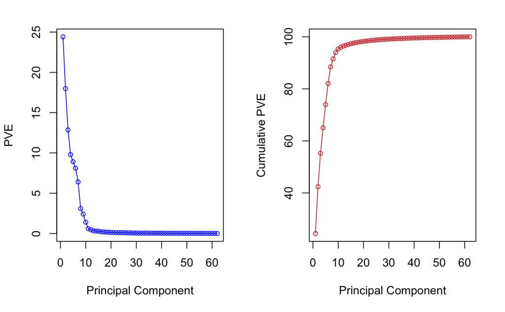

```r
pve <- 100 * pson_pca$sdev^2 / sum(pson_pca$sdev^2)
par(mfrow = c(1, 2))
plot(pve,
     type = "o", cex = 0.8,
     ylab = "PVE", xlab = "Principal Component", col = "blue"
)
plot(cumsum(pve),
     type = "o", cex = 0.8,
     ylab = "Cumulative PVE", xlab = "Principal Component", col = "brown3"
)
```

## Visualizing patterns and groups with PCA

The first two PCs account for a lot of the variance, > 40%. The first 10 PCs account for almost all of the variance. Let’s see if the first two PCs, PC1 and PC2, reveal any patterns in our data.

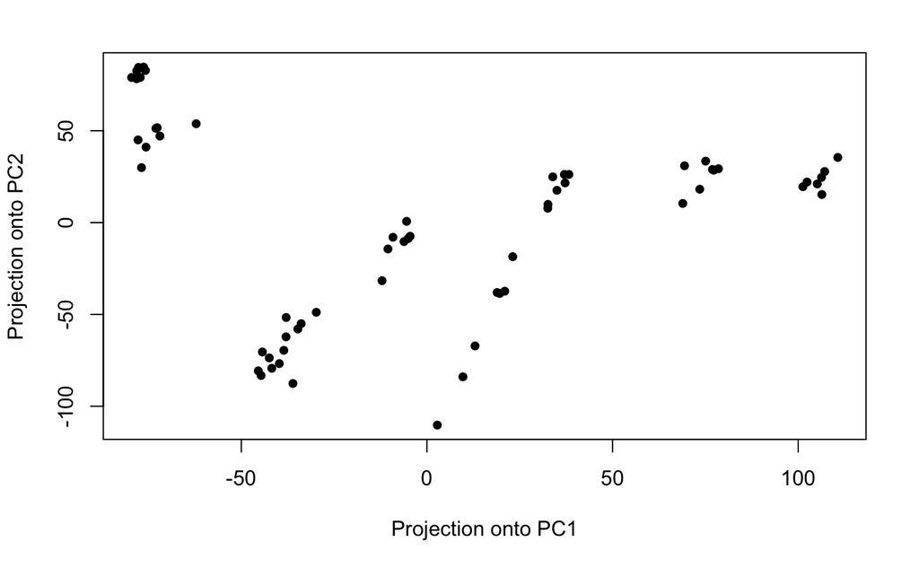

```r
plot(pson_pca$x[, 1:2],
     pch = 19, cex = 0.8,
     xlab = "Projection onto PC1", ylab = "Projection onto PC2"
)
```

Each point gives the coordinates of a sample/cell line in PC space. It’s a nice pattern with some potential. Does is have meaning for our data set? Let’s color the points by cell line type and diagnosis.

```r
cell_speeds_df <- subset(pson_motil_tidy_df, summary_metric == "speed_um_hr")
names(cell_speeds_df)
```

```
 [1] "id_motil"                      "summary_metric"                "average_value"
 [4] "standard_deviation"            "standard_error"                "total_number_of_cells_tracked"
 [7] "sample"                        "id_expr"                       "diagnosis"
[10] "cellType"                      "catalogNumber"                 "cellLine"
[13] "experimentalCondition"         "stiffness"                     "stiffness_units"
[16] "surface"                       "laminate"                      "organ"
[19] "tumorType"                     "stiffness_norm"                "average_value_scaled"
```

We will color by `cellLine` and `diagnosis`, and it is possible to explore other relationships as well.

Here is a simple function for coloring points by type — we’ll use another one of the “*Color Brewer*” palettes that we learned about in Module 2.

```r
color_by_type <- function(vec) {
  nn <- length(unique(vec))
  cols <- RColorBrewer::brewer.pal(nn, "Set1")
  return(cols[as.numeric(as.factor(vec))])
}
```

First, let’s color the points in the PC2 vs. PC1 space according to diagnosis. We’ll adjust the transparency a bit with the `alpha()` function, such that overlapping points are easier to see.

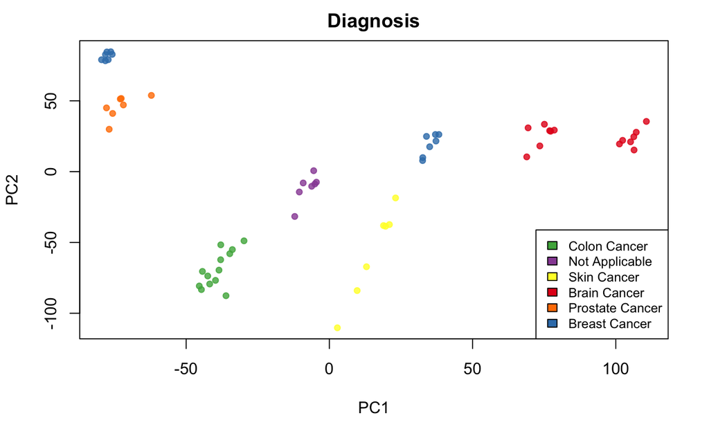

```r
colors <- color_by_type(unique(cell_speeds_df$diagnosis))
diag <- unique(cell_speeds_df$diagnosis)
plot(pson_pca$x[, c(1, 2)],
     col = scales::alpha(color_by_type(cell_speeds_df$diagnosis), 0.8),
     main = "Diagnosis", pch = 19, cex = 0.8
)
legend("bottomright", fill = colors, legend = diag, cex = 0.8)
```

We can use the same approach to color points based on cell line name.

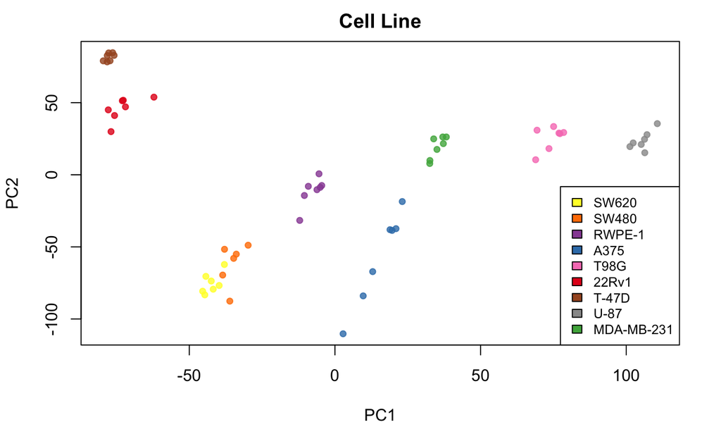

```r
colors <- color_by_type(unique(cell_speeds_df$cellLine))
cell <- unique(cell_speeds_df$cellLine)
plot(pson_pca$x[, c(1, 2)],
     col = scales::alpha(color_by_type(cell_speeds_df$cellLine), 0.8),
     main = "Cell Line", pch = 19, cex = 0.8
)
legend("bottomright", fill = colors, legend = cell, cex = 0.8)
```

T-47D and MDA-MB-231, two breast cancer cell lines form distinct well-separated groups. Can you think of reasons why these points might not be grouped together?

Sometimes we can pick out patterns and information more easily by encoding multiple layers of data in our plot. For example, we can simultaneously look at cell line (color) and diagnosis (label) to more easily see how points relate to each other according to these variables.

```r
colors <- color_by_type(unique(cell_speeds_df$cellLine))
cell <- unique(cell_speeds_df$cellLine)
plot(pson_pca$x[, c(1, 2)],
     main = "Cell Line", pch = 19, cex = 0
)
text(pson_pca$x[, c(1, 2)],
     labels = gsub(" Cancer", "", cell_speeds_df$diagnosis),
     col = scales::alpha(color_by_type(cell_speeds_df$cellLine), 0.8),
     pos = 3, offset = 0, cex = 0.8)
```

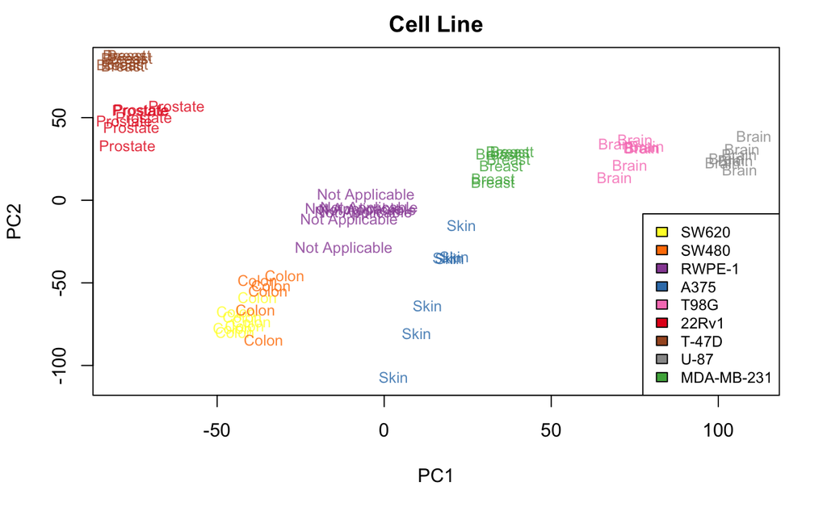

```r
legend("bottomright", fill = colors, legend = cell, cex = 0.8)
```

We see a nice pattern in the data: In (PC1, PC2) space, the cell lines are nicely separated. Note that the two breast cancer cell lines do NOT cluster together. In fact, the “MDA-MB-231” cell line appears more closely related to several other cancer types than to the “T-47D” cell line — why might this be?

# PCA with patient data from TCGA

## Load the data

We’ll shortcut things here again, and let you run the chunk below to get the data in the right format for the next steps.

```r
load(file.path(data_dir, "tcga_brca_expr_gene_info.RData"))
load(file.path(data_dir, "tcga_brca_expr_norm_df.RData"))
load(file.path(data_dir, "tcga_brca_clinical_df.RData"))
x1 <- names(brca_expr_norm_df)[-1]
x2 <- brca_clinical_df[["bcr_patient_barcode"]]
sample.names <- intersect(x1, x2)
sample.names <- sort(sample.names)
I <- match(sample.names, names(brca_expr_norm_df))
I <- c(1, I)
brca_expr_norm_df <- brca_expr_norm_df[, I]
I <- match(sample.names, brca_clinical_df[["bcr_patient_barcode"]])
brca_clinical_df <- brca_clinical_df[I, ]
brca_expr_norm_df2 <- merge(x = gene_df, y = brca_expr_norm_df,
                            by.x = "gene_id",  by.y = "gene_id")
brca_expr_mat <- as.matrix(brca_expr_norm_df2[, -c(1:5)])
rownames(brca_expr_mat) <- brca_expr_norm_df2$symbol
brca_log_mat <- log2(1 + brca_expr_mat)
```

Take a look at `brca_log_mat`:

```r
brca_log_mat[1:5, 1:5]
```

```
         TCGA-3C-AAAU TCGA-3C-AALI TCGA-3C-AALJ TCGA-3C-AALK TCGA-4H-AAAK
TSPAN6      7.5636463     7.705439     9.975045    10.110718     9.881960
TNMD        0.4272843     1.061776     5.353718     1.164271     2.506120
DPM1        9.0367945     9.662019     9.919403     8.859174     8.928912
SCYL3       8.3493520    10.607275     8.395877     9.103957     8.704889
C1orf112    6.9691735     8.106778     7.922947     7.776269     7.495535
```

What step are we missing before calculating PCA (**note:** we’re still interested in looking at the relationships between *samples*)?

```r
# Fill in the command here to "rotate" the matrix to get our data ready for PCA
brca_pca_mat <- t(brca_log_mat) # TODO: DELETE BEFORE ACTIVITY
```

## Calculating PCA

Implementing the PCA algorithm in R is now straightforward. This will take a bit longer than the PS-ON example above — take a moment to ask questions or look ahead to the next steps!

```r
brca_pca <- prcomp(brca_pca_mat)
dim(brca_pca$x)
```

```
[1] 1083 1083
```

```r
brca_pca$x[1:5,1:5]
```

```
                   PC1       PC2        PC3        PC4        PC5
TCGA-3C-AAAU -56.61926  41.33468  -5.566986  18.938057 -36.728384
TCGA-3C-AALI  12.26897  18.51457 -35.538525 -45.265949   1.104241
TCGA-3C-AALJ -11.48759  19.85753 -40.409893 -35.419112 -18.948293
TCGA-3C-AALK -12.88121 -35.45116 -36.698849   4.173563  24.755150
TCGA-4H-AAAK -13.95289 -31.62926 -20.154610  16.568536  22.762430
```

Let’s look at the percent variance explained (or accounted for) by the principal components.

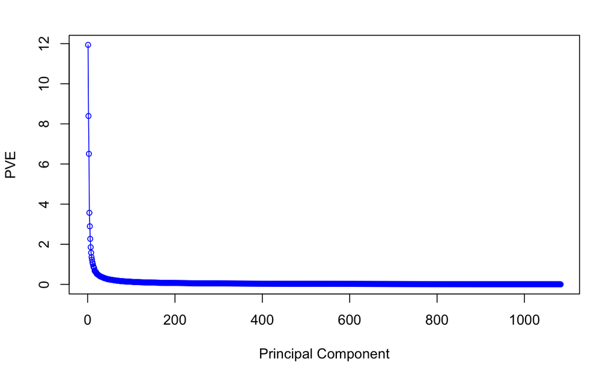

```r
pve <- 100 * brca_pca$sdev^2 / sum(brca_pca$sdev^2)
plot(pve, type = "o", cex = 0.8,
     ylab = "PVE", xlab = "Principal Component", col = "blue")
```

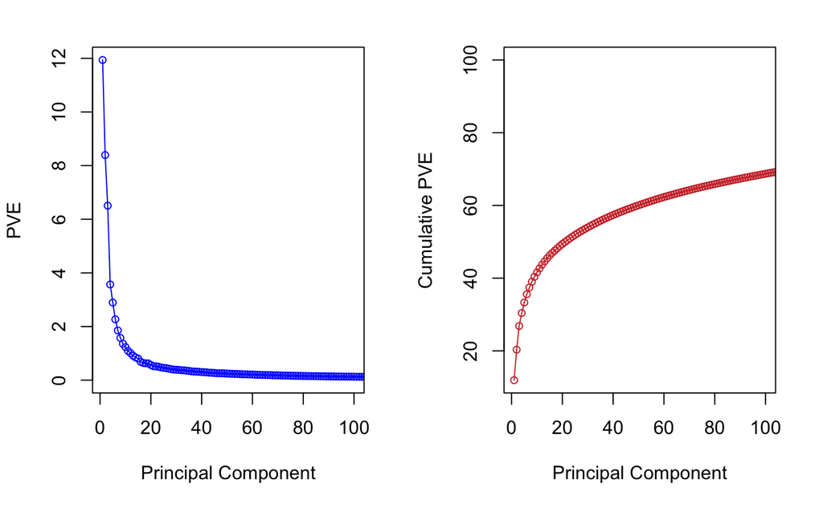

```r
par(mfrow = c(1, 2))
plot(pve, type = "o", cex = 0.8,
     ylab = "PVE", xlab = "Principal Component",
     xlim = c(1, 100), col = "blue")
plot(cumsum(pve), type = "o", cex = 0.8,
     ylab = "Cumulative PVE", xlab = "Principal Component",
     xlim = c(1, 100), col = "brown3")
```

Still a bit hard to eyeball from the plots… We can also print out the percentages to get a better sense for how they’re increasing:

```r
data.frame(PC = 1:10,
           PVE = round(pve[1:10], 0),
           Cumulative.PVE = round(cumsum(pve)[1:10], 0))
```

| PC | PVE | Cumulative.PVE |
| --- | --- | --- |
| 1 | 12 | 12 |
| 2 | 8 | 20 |
| 3 | 7 | 27 |
| 4 | 4 | 30 |
| 5 | 3 | 33 |
| 6 | 2 | 36 |
| 7 | 2 | 37 |
| 8 | 2 | 39 |
| 9 | 1 | 40 |
| 10 | 1 | 42 |

In contrast to the PSON PCA where the first two PCs account for 40% of the variance, the first two PCs for the TCGA brca analysis account for only 20% of the variance. However, for large microarray data sets, this is considered pretty good, and often PC1 and PC2 carry a fair amount of useful information.

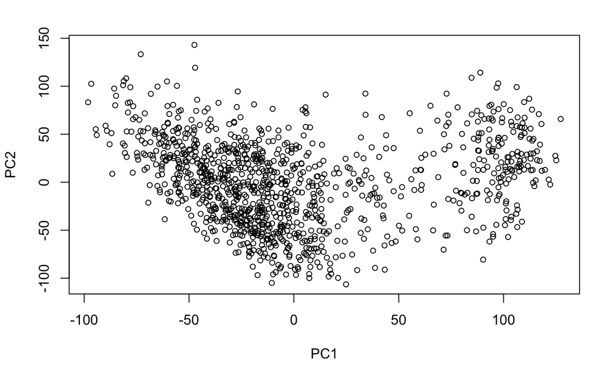

```r
plot(brca_pca$x[, c(1, 2)], cex = 0.8)
```

We see roughly two clusters. Do these have biologial meaning? What clinical information do we have on the TCGA brca samples?

```r
names(brca_clinical_df)
```

```
 [1] "bcr_patient_uuid"
 [2] "bcr_patient_barcode"
 [3] "acronym"
 [4] "gender"
 [5] "vital_status"
 [6] "days_to_birth"
 [7] "days_to_last_followup"
 [8] "days_to_initial_pathologic_diagnosis"
 [9] "age_at_initial_pathologic_diagnosis"
[10] "icd_10"
[11] "tissue_retrospective_collection_indicator"
[12] "icd_o_3_histology"
[13] "tissue_prospective_collection_indicator"
[14] "history_of_neoadjuvant_treatment"
[15] "icd_o_3_site"
```

[output cut: 30 more lines]

Ok, so we have quite a lot of information. Let’s consider estrogen receptor (ER) status. We considered this in the lecture for a different brca set. I am including lines to pull the progeterone receptor (PR) and the receptor tyrosine kinase erbB-2 (HER2) for your examination later.

```r
ER_status <- brca_clinical_df$breast_carcinoma_estrogen_receptor_status
```

What values are encompassed by estrogen receptor status in the brca clinical features data frame? How many samples are labeled with each value?

```r
# one way to check this is to loop through each unique value and then count
# the occurrences of each
unique_status <- unique(ER_status)
for (i in 1:length(unique_status)) {
  print(c(unique_status[i], length(ER_status[ER_status == unique_status[i]])))
}
```

```
[1] "Positive" "797"
[1] "Negative" "236"
[1] "[Not Evaluated]" "48"
[1] "Indeterminate" "2"
```

```r
# another way to do this is with the `table()` function!
table(ER_status)
```

```
ER_status
[Not Evaluated]   Indeterminate        Negative        Positive
             48               2             236             797
```

## Visualizing patterns and groups with PCA

We’ll color the samples in the PC1/PC2 projection plot according to ER status.

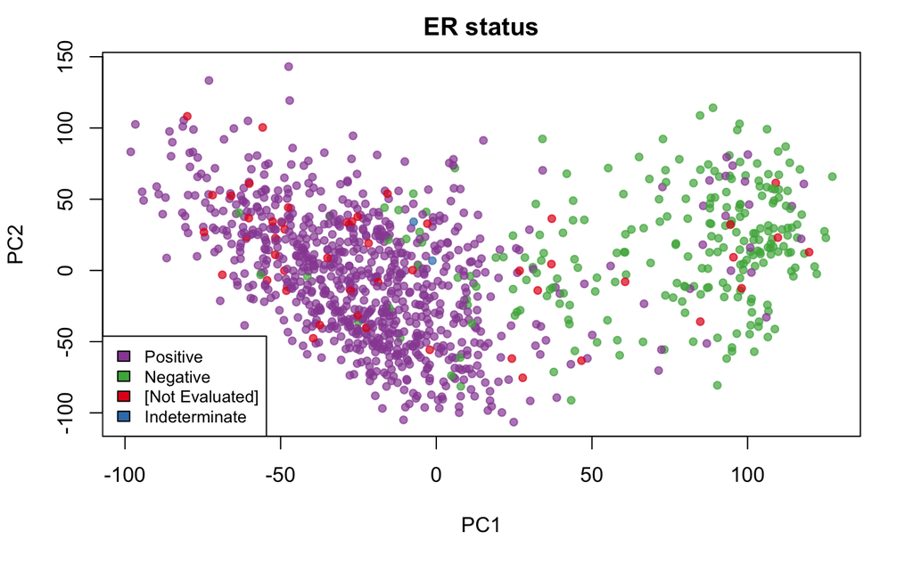

```r
colors <- color_by_type(unique(ER_status))
status <- unique(ER_status)
plot(brca_pca$x[, c(1, 2)],
     col = scales::alpha(color_by_type(ER_status), 0.7),
     main = "ER status", pch = 19, cex = 0.8
)
legend("bottomleft", fill = colors, legend = status, cex = 0.8)
```

# mini-DREAM Challenge

**QUESTION:** Does triple-negative status correspond to major variation among TCGA breast cancer samples? If so, do we expect this variation to relate positively or negatively to metastatic outcomes? What genes individual genes might be driving this variation?

Triple-negative breast cancers are generally diagnosed based on the lack of three receptors known to fuel most breast cancers: estrogen receptors (ER), progesterone receptors (PR) and human epidermal growth factor receptor 2 (HER2). The most successful treatments for breast cancer target these receptors.

## PART 1: Inspecting the other 2/3 of “triple”

Take a look at how the expression of PR and HER2 relate to the first principal component (PC1) in the data.

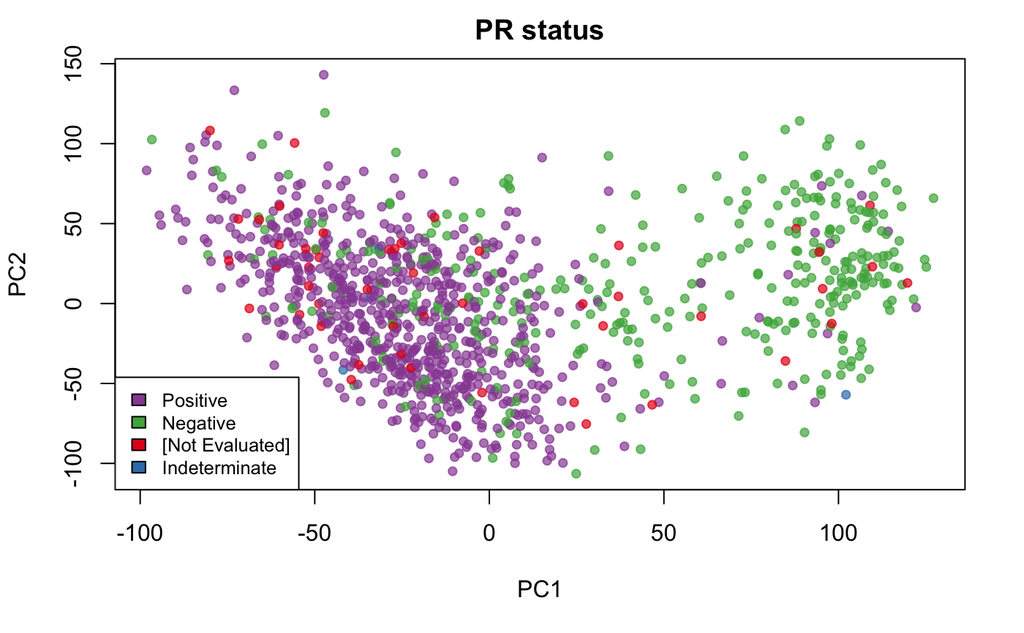

```r
# Replace the blanks with the variable name for PR status (remember that PR
# is short for "progesterone receptor")
# TODO: REPLACE COLUMN NAME WITH "_____" BEFORE ACTIVITY
PR_status <- brca_clinical_df$breast_carcinoma_progesterone_receptor_status
colors <- color_by_type(unique(PR_status))
status <- unique(PR_status)
plot(brca_pca$x[, c(1, 2)],
     col = scales::alpha(color_by_type(PR_status), 0.7),
     main = "PR status", pch = 19, cex = 0.8
)
legend("bottomleft", fill = colors, legend = status, cex = 0.8)
```

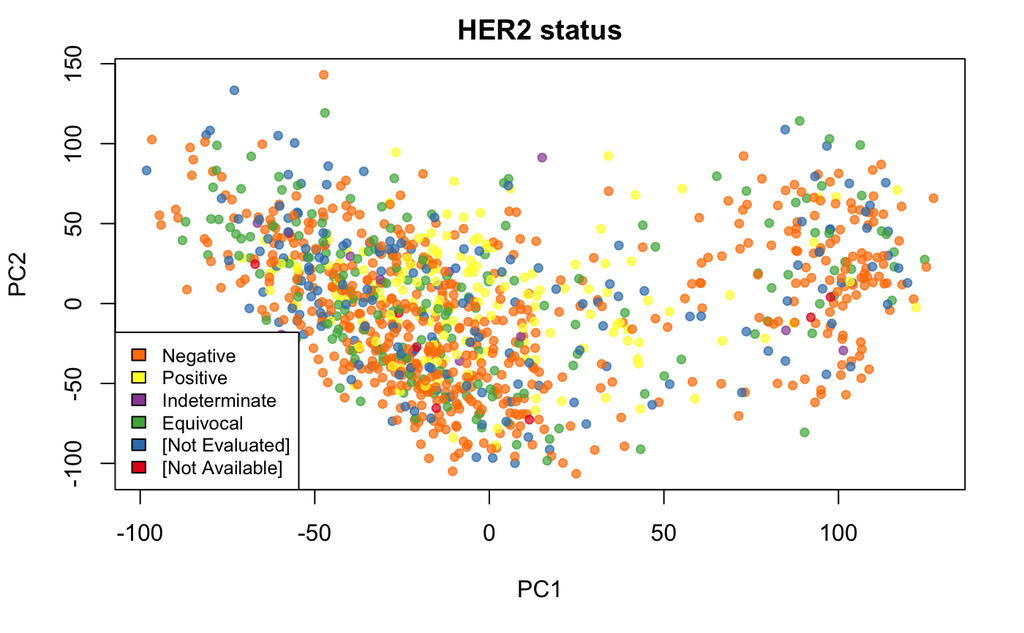

```r
# Replace the blanks with the variable name for HER2 status. Note: we're
# specifically looking for HER2 status determined from immunohistochemistry
# lab processing
# TODO: REPLACE COLUMN NAME WITH "_____" BEFORE ACTIVITY
HER2_status <- brca_clinical_df$lab_proc_her2_neu_immunohistochemistry_receptor_status
colors <- scales::alpha(color_by_type(unique(HER2_status)))
status <- unique(HER2_status)
plot(brca_pca$x[, c(1, 2)],
     col = scales::alpha(color_by_type(HER2_status), 0.7),
     main = "HER2 status", pch = 19, cex = 0.8
)
legend("bottomleft", fill = colors, legend = status, cex = 0.8)
```

Which of the two PC2 vs. PC1 plots is most informative? One of the two receptors should show better separation of “Positive” and “Negative” status along the PC1 axis.

```r
# fill in "PR" or "HER2"
my_pc1_receptor <- "PR" # TODO: REPLACE WITH "" FOR ACTIVITY
```

## PART 2: Triple-negative status and outcome

First, check your answer! If the expression status of one of these two genes is less informative, then a “double negative” status based on only ER and the more informative gene should show greater separation than the when all 3 genes are included.

```r
less_informative <- HER2_status # fill in "HER2_status" or "PR_status"
more_informative <- PR_status # fill in "HER2_status" or "PR_status"
triple_negative <- (
  ER_status == "Negative" &
  more_informative == "Negative" &
  less_informative == "Negative"
)
double_negative <- (
  ER_status == "Negative" &
  more_informative == "Negative"
)
par(mfrow = c(1, 2))
colors_trip <- scales::alpha(color_by_type(unique(triple_negative)))
status_trip <- unique(triple_negative)
plot(brca_pca$x[, c(1, 2)],
     col = scales::alpha(color_by_type(triple_negative), 0.5),
     main = "Triple-negative status", pch = 19, cex = 0.8
)
legend("bottomleft", fill = colors_trip, legend = status_trip, cex = 0.8)
```

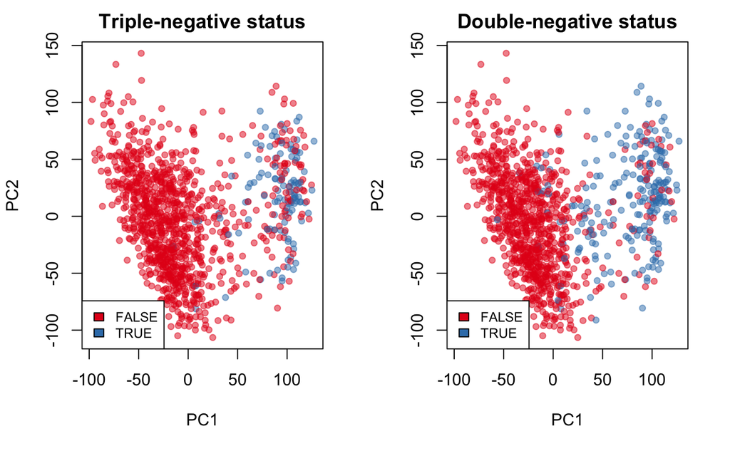

```r
colors_doub <- scales::alpha(color_by_type(unique(double_negative)))
status_doub <- unique(double_negative)
plot(brca_pca$x[, c(1, 2)],
     col = scales::alpha(color_by_type(double_negative), 0.5),
     main = "Double-negative status", pch = 19, cex = 0.8
)
legend("bottomleft", fill = colors_doub, legend = status_doub, cex = 0.8)
```

Assume that PC1 is *positively correlated* with metastasis (we don’t know for sure yet whether it is or not). If that were the case, would “triple negative” be more or less likely to be associated with metastatic samples?

```r
# fill in "more" or "less"
my_tripleneg_met_association <- "more" # TODO: REPLACE WITH "" FOR ACTIVITY
```

## PART 3: Connecting PC1 to individual genes

PCA calculates loading values that rank, in a relative sense, how important genes are to a particular principal component. Look again at the information PCA provides:

```r
names(brca_pca)
```

```
[1] "sdev"     "rotation" "center"   "scale"    "x"
```

The `rotation` element contains loading values for each principal component (column) on each gene (rows). Let’s create a new variable to store these values.

```r
# Create a matrix of loading values
loading_values_mat <- brca_pca$rotation
```

For example, the first column of the loading value matrix contains the loading values for PC1 on each gene. Sort the loading values for PC1 in increasing order; these have the most negative values for PC1.

```r
# Sort and inspect PC1 loading values
pc1_loadings <- loading_values_mat[, 1]
pc1_loadings_sorted <- sort(pc1_loadings, decreasing = FALSE)
# Get the first 6 values from `pc1_loadings_sorted`
head(pc1_loadings_sorted)
```

```
       AGR3        TFF1        ESR1        TFF3     C1orf64        AGR2
-0.06289317 -0.05814906 -0.05189125 -0.05133283 -0.05036492 -0.04952857
```

> You should see the following output.

```
       AGR3        TFF1        ESR1        TFF3     C1orf64        AGR2
-0.06289317 -0.05814906 -0.05189125 -0.05133283 -0.05036492 -0.04952857
```

Consider the first few genes. Search for one in the Human Protein Atlas (HPA), https://www.proteinatlas.org/. Click on the “pathology” link to learn more about this gene’s role in different cancers. Is the gene highly expressed in breast cancer? Does it appear to be prognostic of breast cancer?

```r
# Enter the name of your gene here. It should match one of the 6 names above.
my_hpa_gene <- "TFF1" # TODO: REPLACE WITH "" FOR ACTIVITY
# Look at the section named "RNA EXPRESSION OVERVIEW". Is breast cancer one
# of the diagnoses listed as "tissue enhanced"? Fill in "yes" or "no".
my_hpa_is_enchanced <- "yes" # TODO: REPLACE WITH "" FOR ACTIVITY
# Look at the section named "PROGNOSTIC SUMMARY". Is the gene reported to be a
# prognostic marker for breast cancer? Fill in "yes" or "no".
my_hpa_is_prognostic <- "yes" # TODO: REPLACE WITH "" FOR ACTIVITY
```

## Submitting the prediction

You’re now ready to submit the prediction. Just run the chunk below, a file with your prediction will be uploaded to Synapse and submitted to the challenge. You’ll be able to see the results of your prediction on the mini-DREAM scoreboards, with the submission ID that gets printed below.

```r
# If you submitted for Module 0, this should work.
# synLogin(silent = TRUE)
submission <- submit_module_answers(module = 3, local = TRUE)
```

[output not shown]

Congrats — you’ve reached the end of **Module 3**! You can now return to the **mini-DREAM Challenge** site on Synapse.

| pc1_receptor | tripleneg_met_association | hpa_gene | hpa_is_enchanced | hpa_is_prognostic | comment |
| --- | --- | --- | --- | --- | --- |
| PR | more | TFF1 | yes | yes | Yep. For some reason, PR definitely seems to be more associated with PC1 than HER2. I found that triple-negative samples were more prevalent when PC1 values were high. If PC1 were positively correlate… |